# Graphs with R and Neo4j

Brock Tibert

3/4/2019

## Setup

This post will attempt to use the new neo4r `R` package and update [Nicole’s awesome work](http://nicolewhite.github.io/neo4j-rstats/graphs-r-neo4j/#1) using some of the newer packages out there, namely rtweet.

## The Data Model

Nicole’s data model looking something like this:

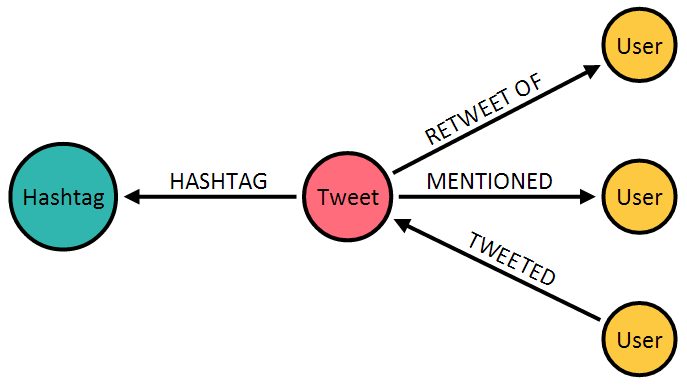

I am going to keep this model for now, but update the data we collect for this post to include the following hashtags:

- neo4j
- rstats
- r4ds

## Get the data from Twitter

First, make sure that you have `rtweet` installed.

```r
install.packages("rtweet")
```

I won’t go into the full details of getting setup with the Twitter API, but if this is your first time playing around, check out [the guide](https://rtweet.info/articles/auth.html) for help getting up and running.

> If you ever want to see what your R session has for environment variables set, you can use `Sys.getenv()`.

Now we simply need to query Twitter’s API for tweets with the hashtags for this post.

```r
TAGS = "#rstats OR #r4ds OR #neo4j"
rt = search_tweets(q = TAGS,
                   n = 18000,
                   include_rts = TRUE)
```

## Parse into Neo4j